# Sysconfig Standalone User Guide

# Using SysConfig with IAR Workbench

If you are using the IAR toolchain, you can use SysConfig as a standalone desktop tool to generate the configuration files to be compiled and linked with your application. In order to do so you have to open SysConfig from the IAR EWARM IDE like described below. If you open device configurations with SysConfig otherwise some parameters provided by the IDE will be missing.

1. Install SysConfig as a standalone tool ([download here](http://downloads.ti.com/ccs/esd/sysconfig/)) within the default location (`C:\ti`).
2. Open IAR and follow these steps to configure it to use the correct viewer for *.syscfg files:

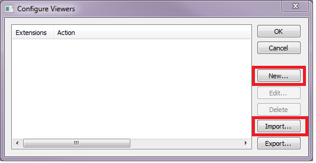

   b. Navigate to the SDK installation directory `<SDK_INSTALL_DIR>\tools\iar\` and select the file `sysconfig_iar_setup.xml` like in the image shown below.

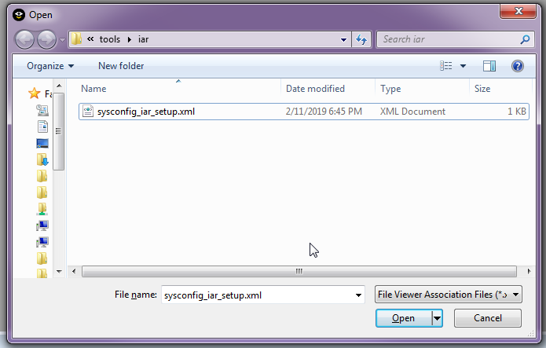

   c. Alternatavily you can add the configuration manually by pressing the **New** button:
   - Choose **Tools > Configure Viewers** from the menus, and then click **New**.
   - Type .syscfg in the **File name extensions** field.
   - Select the Command line option and type the following into the field: `$SYSCONFIG_ROOT$\nw\nw.exe $SYSCONFIG_ROOT$ --compiler iar --product $SIMPLELINK_CC32XX_SDK_INSTALL_DIR$\.metadata\product.json --output $PROJ_DIR$ $FILE_PATH$`

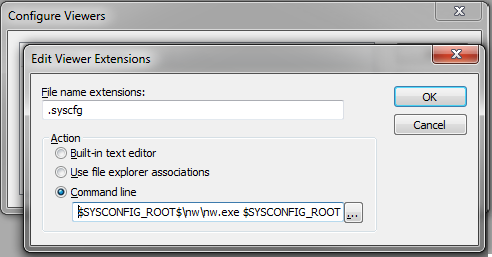

3. Follow these steps to import custom argument variables into IAR:

   a. Choose **Tools > Configure Custom Argument Variables** from the menus.

   b. Choose the **Workspace** or **Global** tab depending on how you want to apply the variables.

   c. Click the **Import** button and browse to `\tools\iar` within your SDK installation. Select the `*.custom_argvars` file provided there and click **OK**.

   d. Click the **Edit Variable** button and change the path of `SYSCONFIG_ROOT` according to the location of your SysConfig installation.

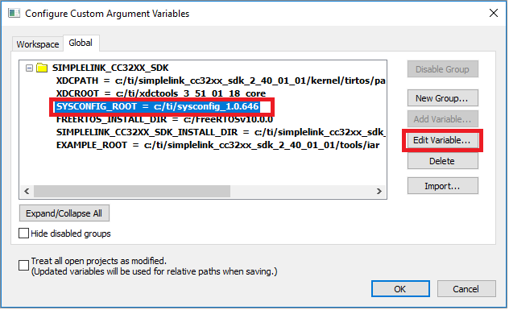

4. If you have not done so already, create a new IAR workspace.
5. Follow these steps to add a project from one of the examples in the SDK’s `\examples` folder or `\examples\sysconfig_preview` folder if you are using an older SDK.

   a. Choose **Project > Add Existing Project** from the menus.

   b. Within your SDK installation, for this example browse to `\examples\rtos\CC3235S_LAUNCHXL\demos\power_measurement\freertos\iar`

   c. Add the `power_measurement.ewp` file.
6. Double click on the *.syscfg file in your project.
7. This shall open SysConfig and offers you to adapt drivers, IO Pins and other settings.

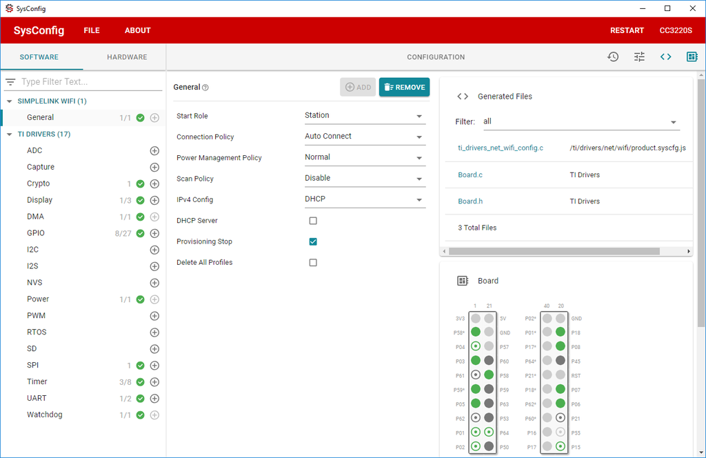

8. Save your changes and switch back to IAR EWARM. Saving the configuration in SysConfig does not yet generate new driver and other files; It just saves the configuration.
9. Rebuild the project to perform the custom build step, which uses command line scripts to adapt your IAR project to the changes made in SysConfig.  
   If you later on do changes in SysConfig and don’t want to rebuild the whole project you can select the *.syscfg file in your IAR project explorer and compile only that one. This will trigger the creation of driver and other files with the changes you made in SysConfig.  
   After that a simple “Make” will detect all changed files for the IAR compiler and linker tool chain.

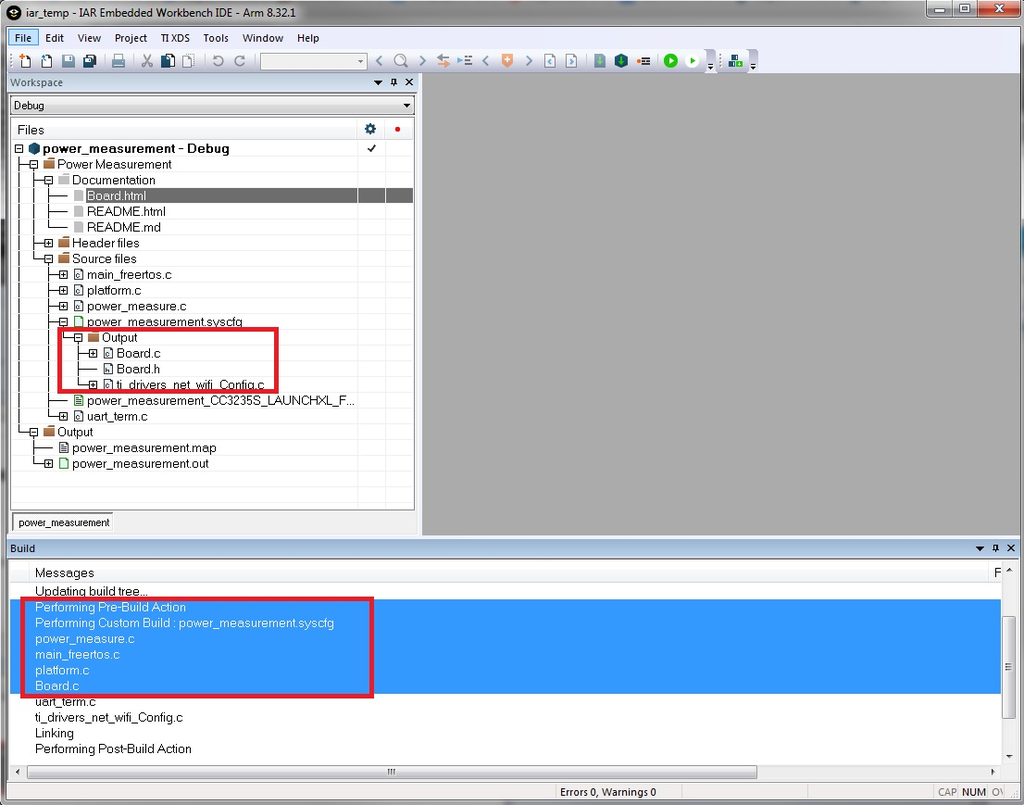

**NOTE**: You can view the custom build configuration by choosing **Project > Options** from the menus and selecting the **Custom Build** category.

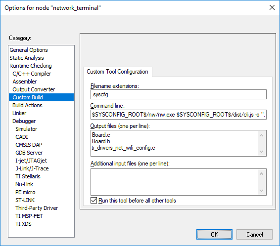